# staff_student_diversity

Merly Klaas

2023-06-08

```r
dat <- full %>%
  select(school_id,
         school_state,
         leadership_diversity,
         teaching_diversity,
         pct_bipoc,
         self_reported_total_enrollment,
         self_reported_locale_rural,
         self_reported_locale_suburban,
         self_reported_locale_urban,
         self_reported_locale_multiple) %>%
  drop_na(pct_bipoc) %>%
  filter(leadership_diversity != 0 |leadership_diversity != 5,
         teaching_diversity != 0|teaching_diversity != 5) %>%
  mutate(scale_bipoc = case_when(pct_bipoc<25 ~ 1,
                                 pct_bipoc>25 & pct_bipoc <50 ~ 2,
                                 pct_bipoc >49 & pct_bipoc<75 ~ 3,
                                 pct_bipoc >74 ~ 4, TRUE ~ NA),
         lead_stu_div = scale_bipoc/leadership_diversity,
         teach_stu_div = scale_bipoc/teaching_diversity,
         lead_stu_prop = case_when(lead_stu_div < "1" ~ "Overly Representative",
                                   lead_stu_div == 1 ~ "Equally Representative",
                                   lead_stu_div > "1" ~ "Under Representative",
                                 #  & lead_stu_div < 3 ,
                                 #  teach_stu_div >=3  ~ "Severely under representative",
                                   TRUE ~ NA),
         teach_stu_prop = case_when(teach_stu_div < "1" ~ "Overly Representative",
                                   teach_stu_div == 1 ~ "Equally Representative",
                                   teach_stu_div > 1 ~ "Under Representative",
                                   #& teach_stu_div < 3 ,
                              #     teach_stu_div >=3  ~ "Severely under representative",
                                   TRUE ~ NA))
```

### Scatter plot for Teaching Diversity

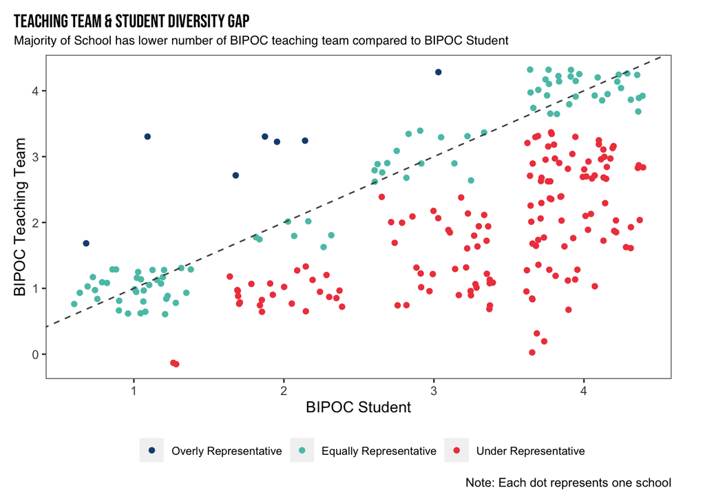

```r
sct_teach <- dat %>%
  select(teaching_diversity,scale_bipoc, teach_stu_prop) %>%
  drop_na() %>%
  filter(teaching_diversity != 5) %>%
  ggplot(aes(scale_bipoc, teaching_diversity)) +
  geom_jitter(aes(color=teach_stu_prop)) +
   geom_abline(intercept = 0,
              slope = 1,
              linetype = "dashed",
              size = 0.5,
              color = transcend_grays[1])+
  labs(title = "Teaching Team & Student Diversity Gap",
       subtitle = "Majority of School has lower number of BIPOC teaching team compared to BIPOC Student",
       x= "BIPOC Student",
       y="BIPOC Teaching Team",
       caption = "Note: Each dot represents one school")+
  scale_color_manual(name= "",
                     values = transcend_cols,
                     breaks=c("Overly Representative",
                             "Equally Representative",
                             "Under Representative")) +

   theme(
     plot.title.position = "plot",
     plot.title = element_text(family = "Bebas Neue", color = "black"),
    plot.subtitle = element_text(family = "sans", size = rel(0.8)),
    plot.background = element_rect(fill="transparent", color=NA),
   panel.background = element_rect(fill="transparent", color=NA),
    panel.border = element_rect(colour = transcend_grays[1],
                                fill = NA),
    strip.text = element_text(size = rel(0.8)),
    plot.margin = margin(10, 24, 10, 10, "pt"),
   # panel.grid.major = element_blank(),
    panel.grid.minor = element_blank(),
    legend.position = "bottom",
   legend.text=element_text(size=8)
   #axis.title = element_blank()
   # axis.ticks = element_blank(),
   # axis.text =element_blank(),
  )
sct_teach
```

```r
#ggsave("finding-5-V3.png", plot = sct_teach, path = here("final_products", "draft-findings"),
 #     width = 8, height = 6, units = "in")
```

### Scatter plot for Leadership Diversity

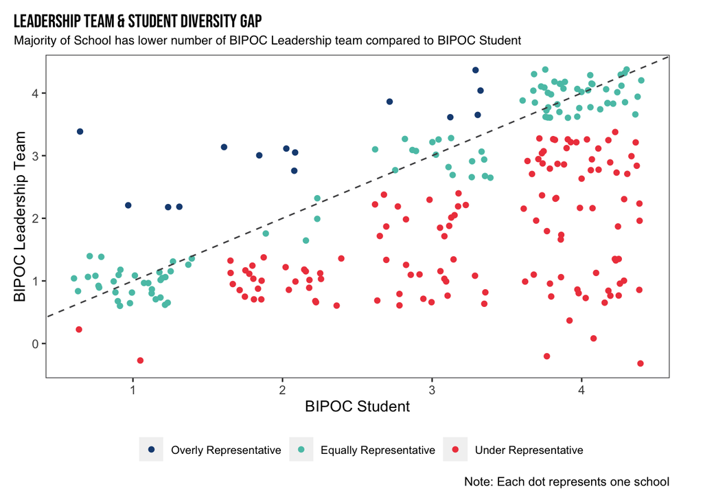

```r
sct_lead <- dat %>%
  select(leadership_diversity,scale_bipoc, lead_stu_prop) %>%
  drop_na() %>%
  filter(leadership_diversity != 5) %>%
  ggplot(aes(scale_bipoc, leadership_diversity)) +
  geom_jitter(aes(color=lead_stu_prop)) +
   geom_abline(intercept = 0,
              slope = 1,
              linetype = "dashed",
              size = .5,
              color = transcend_grays[1])+
  labs(title = "Leadership Team & Student Diversity Gap",
       subtitle = "Majority of School has lower number of BIPOC Leadership team compared to BIPOC Student",
       x= "BIPOC Student",
       y="BIPOC Leadership Team",
       caption = "Note: Each dot represents one school")+
  scale_color_manual(name= "",
                     values = transcend_cols,
                     breaks=c("Overly Representative",
                             "Equally Representative",
                             "Under Representative")) +

   theme(
     plot.title.position = "plot",
     plot.title = element_text(family = "Bebas Neue", color = "black"),
    plot.subtitle = element_text(family = "sans", size = rel(0.8)),
    plot.background = element_rect(fill="transparent", color=NA),
   panel.background = element_rect(fill="transparent", color=NA),
    panel.border = element_rect(colour = transcend_grays[1],
                                fill = NA),
    strip.text = element_text(size = rel(0.8)),
    plot.margin = margin(10, 24, 10, 10, "pt"),
   # panel.grid.major = element_blank(),
    panel.grid.minor = element_blank(),
    legend.position = "bottom",
   legend.text=element_text(size=8)
   #axis.title = element_blank()
   # axis.ticks = element_blank(),
   # axis.text =element_blank(),
  )
sct_lead
```

```r
#ggsave("finding-5b-V3.png", plot = sct_lead, path = here("final_products", "draft-findings"),
   #   width = 8, height = 6, units = "in")
```

### School Leader vs Student Diversity gap

I extracted leaders’ race and recoded them into Bipoc/non-bipoc for each school as binary variable (coded 1 for Bipoc). Then, I calculated percentage of Bipoc leader within each school. I joined this data with percent bipoc student in each school.

In the first graph, I calculated overall percentage of bipoc leaders and bipoc students, then visualized it as bar graph.

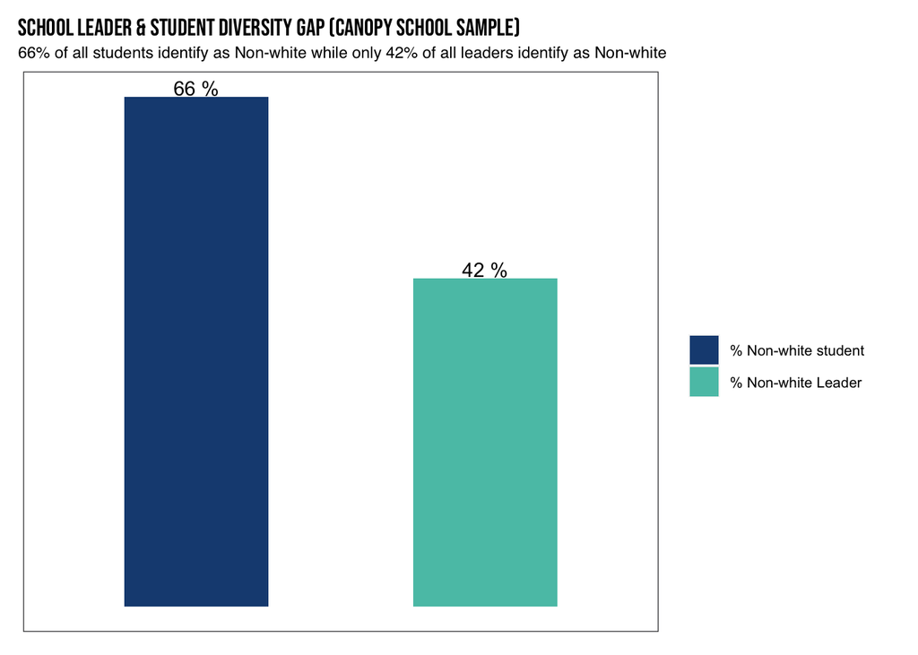

```r
dat2 %>%
  pivot_longer(cols = c(pct_leader_bipoc, pct_bipoc),
               names_to = "category",
               values_to = "pct") %>%
  group_by(category) %>%
  summarise(percent_total = mean(pct)) %>%
  ggplot(aes(x=category, y=percent_total, fill = category)) +
  geom_col(width = .5)+
  geom_text(aes(x=category, y=percent_total, label = paste(round(percent_total,0),"%")), vjust= -.1)+
  scale_fill_manual(name ="",
                    values = transcend_cols,
                    labels=c("% Non-white student","% Non-white Leader"))+
  labs(title = "School Leader & Student Diversity Gap (Canopy School Sample)",
            subtitle = "66% of all students identify as Non-white while only 42% of all leaders identify as Non-white") +
  theme_2()
```

In the second graph, I grouped by state and calculated percent total of bipoc leader and student in each state. I visualized them as dumbbell plot to highlight the racial diversity gap between school leader and student.

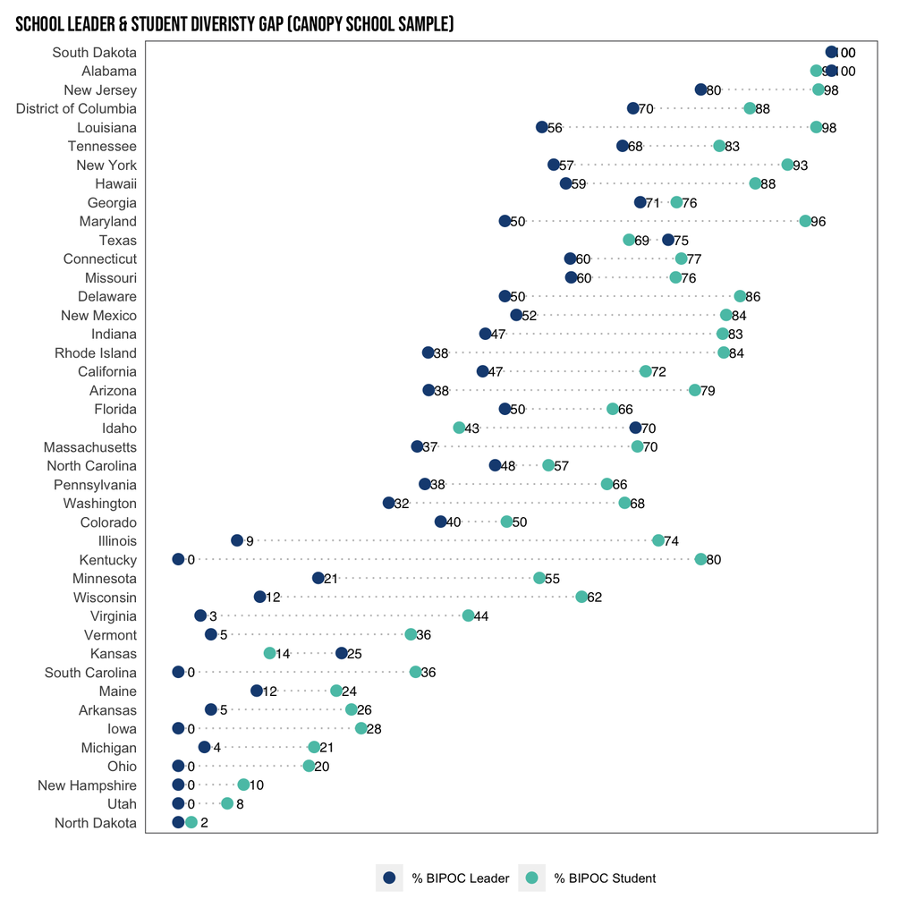

```r
#gap <-
dat2 %>%
  pivot_longer(cols = c(pct_leader_bipoc, pct_bipoc),
               names_to = "category",
               values_to = "pct") %>%
  group_by(school_state, category) %>%
  summarise(percent_total = mean(pct)) %>%
  drop_na() %>%
  ggplot()+
  geom_line(aes(x=percent_total,
                y = fct_reorder(school_state,percent_total),
                group = school_state),
                linetype= "dotted",
            color = "gray") +
  geom_text(aes(x=percent_total, y=school_state, label = round(percent_total,0)),
               nudge_x = 2,
            size = 3,
            family = "sans") +
  geom_point(aes(x=percent_total,
                 y = fct_reorder(school_state,percent_total),
                 color = category),
             size=3,
             show.legend = TRUE) +
  scale_color_manual(name ="",
                    values = transcend_cols,
                    breaks = c("pct_leader_bipoc","pct_bipoc"),
                    labels=c("% BIPOC Leader","% BIPOC Student"))+
  labs(title = "School Leader & Student Diveristy Gap (Canopy School Sample)") +
  theme_3()
```

```r
# ggsave("finding-5.png", plot = gap, path = here("final_products", "draft-findings"),
#        width = 12, height = 8, units = "in")
```

school leader and student Gap by State

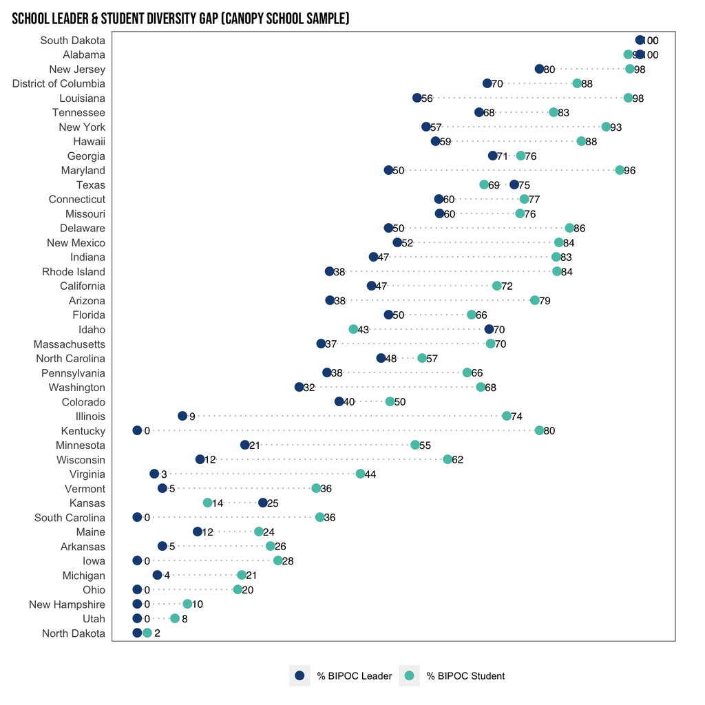

```r
#gap <-
dat2 %>%
  pivot_longer(cols = c(pct_leader_bipoc, pct_bipoc),
               names_to = "category",
               values_to = "pct") %>%
  group_by(school_state, category) %>%
  summarise(percent_total = mean(pct)) %>%
  drop_na() %>%
  ggplot()+
  geom_line(aes(x=percent_total,
                y = fct_reorder(school_state,percent_total),
                group = school_state),
                linetype= "dotted",
            color = "gray") +
  geom_text(aes(x=percent_total, y=school_state, label = round(percent_total,0)),
               nudge_x = 2,
            size = 3,
            family = "sans") +
  geom_point(aes(x=percent_total,
                 y = fct_reorder(school_state,percent_total),
                 color = category),
             size=3,
             show.legend = TRUE) +
  scale_color_manual(name ="",
                    values = transcend_cols,
                    breaks = c("pct_leader_bipoc","pct_bipoc"),
                    labels=c("% BIPOC Leader","% BIPOC Student"))+
  labs(title = "School Leader & Student Diversity Gap (Canopy School Sample)") +
  theme_3()
```

### Dumbbell school leader and student Gap by Locale

[figure not shown]

```r
locale <-
  anova_dat %>%
 filter(category == "pct_leader_bipoc" | category == "pct_bipoc") %>%
  mutate(locale = str_to_title(locale)) %>%
  group_by(locale, category) %>%
  summarise(percent_total = weighted.mean(pct,self_reported_total_enrollment, na.rm = TRUE)) %>%
  drop_na() %>%
  pivot_wider(names_from = category,
              values_from = percent_total) %>%
  mutate(gap = paste(round(pct_bipoc - pct_leader_bipoc,0),"%")) %>%
  pivot_longer(cols = c(pct_bipoc, pct_leader_bipoc),
               names_to = "category",
               values_to = "percent_total") %>%
  ggplot()+
  geom_line(aes(x=percent_total,
                y = fct_reorder(locale,percent_total),
                group = locale),
                linetype= "dotted",
            color = "gray") +
  geom_text(aes(x=percent_total, y=locale,
                label = paste(round(percent_total,0),"%")),
               nudge_x = -3,
            size = 3,
            family = "sans",
            fontface="bold") +
  geom_point(aes(x=percent_total,
                 y = fct_reorder(locale,percent_total),
                 color = category),
             size=4,
             show.legend = TRUE) +
    scale_x_continuous(expand = c(0,0),
                     limits = c(0,100)) +
  coord_equal(ratio = 7)+
  scale_color_manual(name ="",
                    values = transcend_cols,
                    breaks = c("pct_leader_bipoc","pct_bipoc"),
                    labels=c("% BIPOC Leader","% BIPOC Student"))+
  labs(title = "School Leader & Student Diversity Gap",
      subtitle ="Overall, 66% of all students identify as BIPOC while only 42% of all school leaders identify as BIPOC") +
   theme(
     plot.title.position = "plot",
    plot.title = element_text(family = "Bebas Neue", color = "black"),
    plot.subtitle = element_text(family = "Sans", size = rel(0.8)),
    plot.background = element_blank(),
    panel.grid.major.x = element_line(color="gray", size= 0.1),
    panel.background = element_blank(),
    axis.title = element_blank(),
   panel.border = element_rect(colour = transcend_grays[1],
                                fill = NA),
    strip.text = element_text(size = rel(0.8)),
    plot.margin = margin(10, 24, 10, 10, "pt"),
    panel.grid.major.y= element_blank(),
    legend.position = "bottom"
  )
locale
```

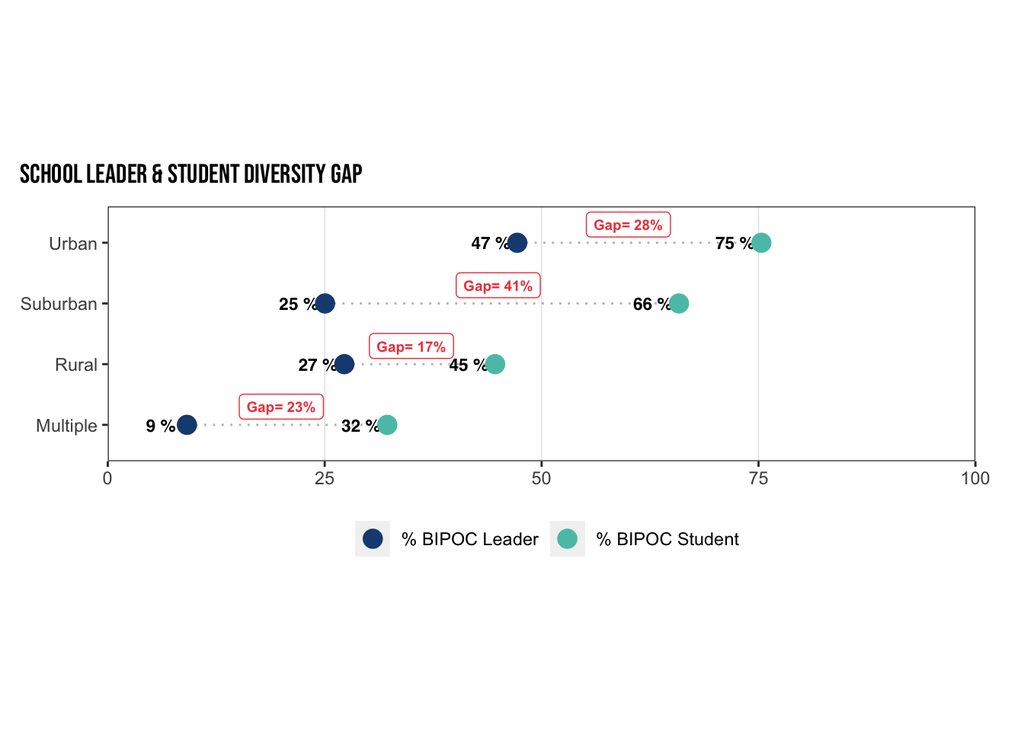

```r
# a data frame with all the annotation info
annotation <- data.frame(
   x = c(60,45,35,20),
   y = c(4.3,3.3,2.3,1.3),
   label = c("Gap= 28%", "Gap= 41%",
             "Gap= 17%", "Gap= 23%")
)

fig <- locale + geom_label(data=annotation, aes( x=x, y=y, label=label),
           color=transcend_cols[3],
           size=2.5 , angle=45, fontface="bold")

fig
```

```r
#ggsave("finding-6-V3.png", plot = fig, path = here("final_products", "draft-findings"),
  #    width = 8, height = 6, units = "in")
```

### t-test:

#### *Does the % of BIPOC leader is significantly different than the % of Bipoc Student?*

Yes! Overall, the percentage of BIPOC leader is significantly lower than the % of Bipoc Student.

```r
t1 <- anova_dat %>%
  filter(category == "pct_leader_bipoc" | category == "pct_bipoc")
  t.test(pct ~ category, data=t1)
```

```
##
##  Welch Two Sample t-test
##
## data:  pct by category
## t = 7.031, df = 447.93, p-value = 7.7e-12
## alternative hypothesis: true difference in means between group pct_bipoc and group pct_leader_bipoc is not equal to 0
## 95 percent confidence interval:
##  16.51007 29.32041
## sample estimates:
##        mean in group pct_bipoc mean in group pct_leader_bipoc
##                       65.23457                       42.31933
```

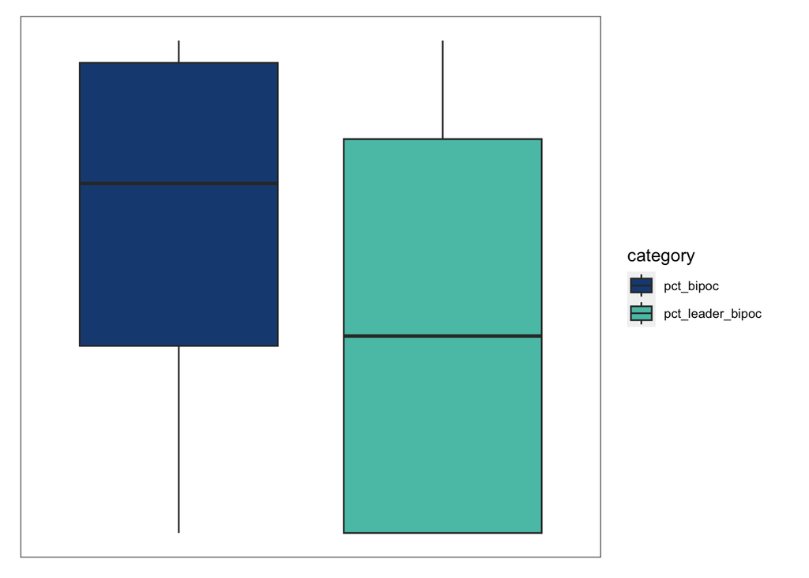

```r
t1 %>%
  ggplot(aes(category, pct, fill=category))+
  geom_boxplot()+
  scale_fill_manual(values = transcend_cols)+
  theme_2()
```

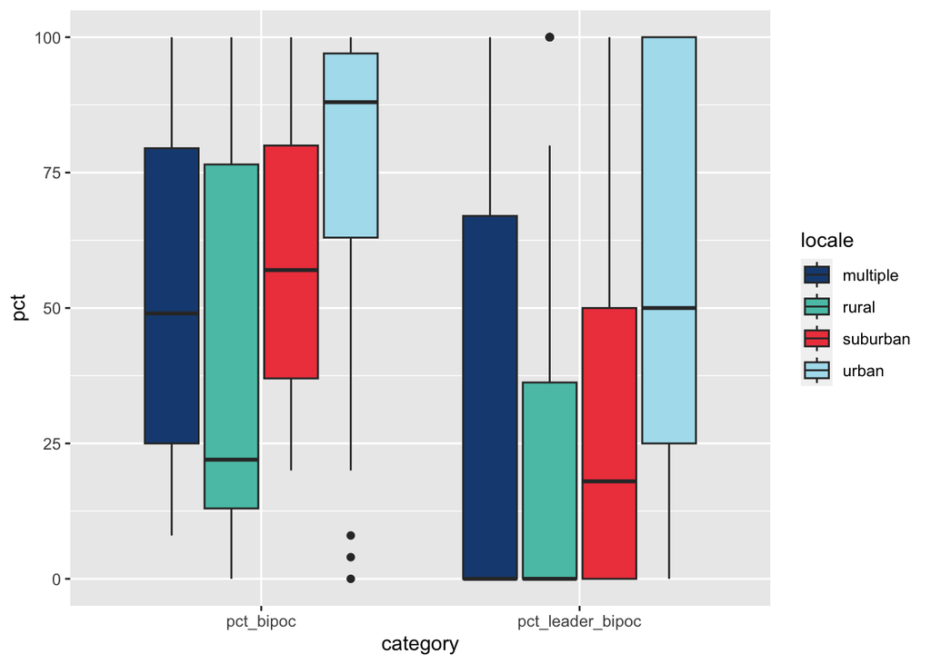

```r
#locale<-
t1 %>%
  ggplot(aes(category, pct, fill=locale))+
  geom_boxplot()+
  scale_fill_manual(values = transcend_cols)
```

```r
# ggsave("finding-6.png", plot = locale, path = here("final_products", "draft-findings"),
#        width = 12, height = 8, units = "in")
```

#### *Does the scaled number of BIPOCof BIPOC teaching team is significantly different than Bipoc Student?*

**Yes! Overall, the percentage of BIPOC teaching team is significantly lower than the % of Bipoc Student.**

Remember that for teaching & leadership team diversity, we use 1 - 4, so does the scale_bipoc

```r
t2 <- anova_dat %>%
  filter(category == "teaching_diversity" | category == "scale_bipoc",
         pct != 5) #answer not sure)

t.test(pct ~ category, data=t2)
```

```
##
##  Welch Two Sample t-test
##
## data:  pct by category
## t = 8.8945, df = 480.85, p-value < 2.2e-16
## alternative hypothesis: true difference in means between group scale_bipoc and group teaching_diversity is not equal to 0
## 95 percent confidence interval:
##  0.7050142 1.1048346
## sample estimates:
##        mean in group scale_bipoc mean in group teaching_diversity
##                         2.991701                         2.086777
```

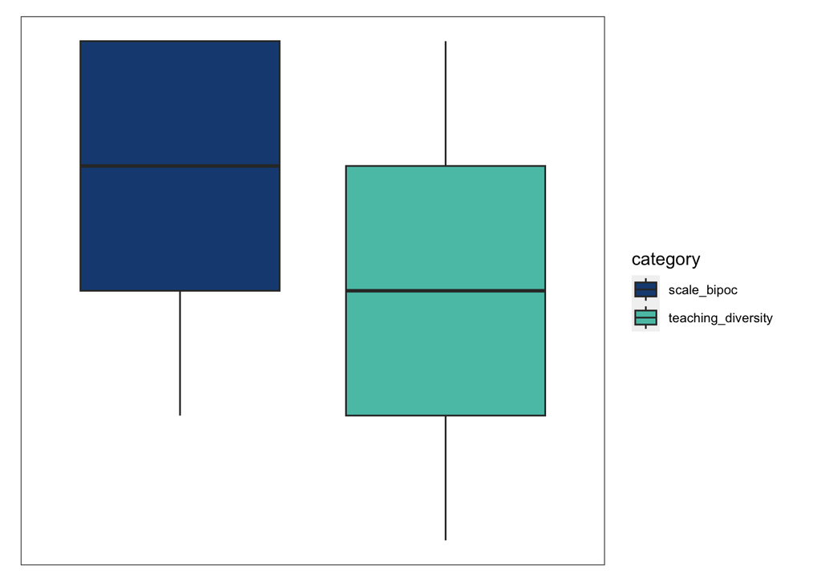

```r
t2 %>%
  ggplot(aes(category, pct, fill=category))+
  geom_boxplot()+
  scale_fill_manual(values = transcend_cols)+
  theme_2()
```

#### *Does the scaled number of BIPOC Leadership team is significantly different than Bipoc Student?*

**Yes! Overall, the scaled number of BIPOC Leadership team is significantly lower than the Bipoc Student.**

```r
t3 <- anova_dat %>%
  filter(category == "leadership_diversity" | category == "scale_bipoc",
         pct != 5) #answer not sure)

t.test(pct ~ category, data=t3)
```

```
##
##  Welch Two Sample t-test
##
## data:  pct by category
## t = -7.5965, df = 478.77, p-value = 1.611e-13
## alternative hypothesis: true difference in means between group leadership_diversity and group scale_bipoc is not equal to 0
## 95 percent confidence interval:
##  -1.0254903 -0.6040027
## sample estimates:
## mean in group leadership_diversity          mean in group scale_bipoc
##                           2.176955                           2.991701
```

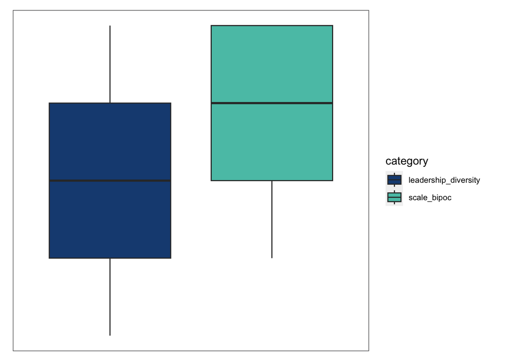

```r
t3 %>%
  ggplot(aes(category, pct, fill=category))+
  geom_boxplot()+
  scale_fill_manual(values = transcend_cols)+
  theme_2()
```

### Anova / F Test

```r
model1 <- aov(pct ~ category * locale, data = t1)
summary(model1)
```

```
##                  Df Sum Sq Mean Sq F value   Pr(>F)
## category          1  63137   63137  58.170 1.33e-13 ***
## locale            3  94070   31357  28.890  < 2e-16 ***
## category:locale   3   1221     407   0.375    0.771
## Residuals       473 513389    1085
## ---
## Signif. codes:  0 '***' 0.001 '**' 0.01 '*' 0.05 '.' 0.1 ' ' 1
## 5 observations deleted due to missingness
```

```r
model2 <- aov(pct ~ category * locale, data = t2)
summary(model2)
```

```
##                  Df Sum Sq Mean Sq F value Pr(>F)
## category          1   98.9   98.88  97.925 <2e-16 ***
## locale            3  120.1   40.02  39.634 <2e-16 ***
## category:locale   3    1.5    0.49   0.483  0.694
## Residuals       475  479.6    1.01
## ---
## Signif. codes:  0 '***' 0.001 '**' 0.01 '*' 0.05 '.' 0.1 ' ' 1
```

```r
model3 <- aov(pct ~ category * locale, data = t3)
summary(model3)
```

```
##                  Df Sum Sq Mean Sq F value   Pr(>F)
## category          1   80.3   80.32  70.774 4.71e-16 ***
## locale            3  129.5   43.16  38.032  < 2e-16 ***
## category:locale   3    1.7    0.56   0.495    0.686
## Residuals       476  540.2    1.13
## ---
## Signif. codes:  0 '***' 0.001 '**' 0.01 '*' 0.05 '.' 0.1 ' ' 1
```